# Problem Set 05

Your Name Here: Group X

Last updated: 2023-03-03

```r
library(tidyverse)
library(readxl)
library(cowplot)
theme_set(theme_cowplot())
```

## Flow control: for loops, part 1

For loops are one of the main methods for iterating through R objects (vectors, tibbles, data.frames, etc.).[^1]. Study and run the following code:

```r
for (ii in 1:10) {
  cat(ii, "\n")
}
```

```
## 1
## 2
## 3
## 4
## 5
## 6
## 7
## 8
## 9
## 10
```

There are a few things to look at here:

- The `for ()` part of the statement set up what will be iterated through (the sequence 1 to 10). At each iteration `ii` takes the next value and can be used within in the loop.
- `ii` is a better choice of iterator name than `i`, because it is easier to search for later. Imagine trying to find `i` in your code.
- `cat()` is a function (“concatenate and print”) that you can use to print output to the screen. The statement here tells R to print each value of `ii` followed by a new line (`"\n"`).
- Until you get comfortable with for loops, it’s often useful to print out the values of the iterator and/or other critical data with each iteration so that you are certain of their values.
- You can also use the function `message()` to print out counters. Try changing the code above to `message(ii)` and see how the output differs.

### Activity

Write you own for loop, choosing a new variable name for the iterator, which will start at 50 and end at 60. Within the loop, print the value of the iterator plus 10.

```r
# FIXME
for (jj in 50:60) {
  cat(jj + 10, "\n")
}
```

```
## 60
## 61
## 62
## 63
## 64
## 65
## 66
## 67
## 68
## 69
## 70
```

Your output should be the sequence 60 to 70.

## Flow control: for loops, part 2

A common way to work with for loops is to iterate through a pre-existing R object. The for loop will take on the values starting with the first value and iterating through to the last value of the object. So far, we have used sequence by 1, but you can iterate through the values of a vector. Here you will just pass the vector name: `for (ii in odds)`.

### Activity

Create a vector (`odds`) that contains the sequence of the odd numbers 1 through 21.

```r
odds <- seq(1, 21, by = 2)
```

Iterate through `odds`, printing out the value of the iterator and the square of the iterator. Separate the values inside `cat()` with a tab (`"\t"`).

```r
# FIXME
for (ij in odds) {
  cat(ij, "\t", ij ^ 2, "\n")
}
```

```
## 1     1
## 3     9
## 5     25
## 7     49
## 9     81
## 11    121
## 13    169
## 15    225
## 17    289
## 19    361
## 21    441
```

Repeat the same loop, but iterate from 1 to the `length()` of `odds`. Inside the loop, extract the element of `odds` that corresponds to the value of the iterator. This construction, where the first line inside the loop extracts a value from the iterator, is much more common, because more often than not, you will need the value of the iterator later in the loop.

```r
# FIXME
for (ji in 1:length(odds)) {
  x <- odds[ji] ^ 2
  cat(ji, "\t", x, "\n")
}
```

```
## 1     1
## 2     9
## 3     25
## 4     49
## 5     81
## 6     121
## 7     169
## 8     225
## 9     289
## 10    361
## 11    441
```

Notice here that the value of the iterator goes from 1 to 11 (the length of `odds`).

## Functions

Functions are reusable pieces of code that perform operations. Although functions can be very complex, best coding practice is to keep functions short and simple. In R, you create functions with the function `function()`.

Below is a function to add 10 to whatever object is passed to it.

```r
add_10 <- function(x) {
  y <- x + 10
  return(y)
}
```

There are a few things to note here:

- Anything within the `()` after `function` are arguments that are passed to the function. In this function, we require an argument `x`. There are mechanisms for allowing optional arguments and specifying default values. You can read about them online (see the R programming resources on Canvas).
- The variable `y` exists inside the function only. It does not move outside the function, until you explicitly say so: `return(y)`.
- We haven’t done any kind of checking to see whether the argument `x` can be added to. If we pass a character vector as `x`, we will get an error. `non-numeric argument to binary operator`. Down the road, you might consider checking the incoming argument(s).

```r
zz <- 100
add_10(x = zz)
```

```
## [1] 110
```

```r
add_10(zz)
```

```
## [1] 110
```

```r
add_10(seq(50, 60, by = 2))
```

```
## [1] 60 62 64 66 68 70
```

```r
# y doesn't change due to the function
y <- 5412
add_10(y)
```

```
## [1] 5422
```

```r
y
```

```
## [1] 5412
```

```r
# y is reassigned to the result of the function
y <- add_10(y)
y
```

```
## [1] 5422
```

### Activity

Write your own function below that takes two arguments. Multiply the arguments and return the value. Try out your function to make sure that it works for both single numerics and numeric vectors. What happens when the vectors are the same length? What happens when they are different lengths?

```r
# FIXME
multiply <- function(x, y) {
  z <- x * y
  return(z)
}

multiply(2, 17.4)
```

```
## [1] 34.8
```

```r
multiply(1:3, 10:12)
```

```
## [1] 10 22 36
```

```r
multiply(10:15, 3.4)
```

```
## [1] 34.0 37.4 40.8 44.2 47.6 51.0
```

```r
multiply(1:3, 5:10) # Think about what is going on here
```

```
## [1]  5 12 21  8 18 30
```

## Sometimes I think George is not being completely honest with me

You and your friend George go to dinner once a week. You agreed that you would flip George’s “lucky” coin to decide who gets to choose the restaurant. Being superstitious, you always pick heads.

After losing several times in a row, you start to get suspicious and begin keeping track. You find that after 20 weeks, you have only chosen the restaurant 5 times.

### Activity

What is the maximum likelihood estimate (MLE) of the probability of heads for this sample from this coin? Test values ($\theta$) from 0.05 to 0.95 in increments of 0.05, and plot the log-likelihood vs. the values for $\theta$.

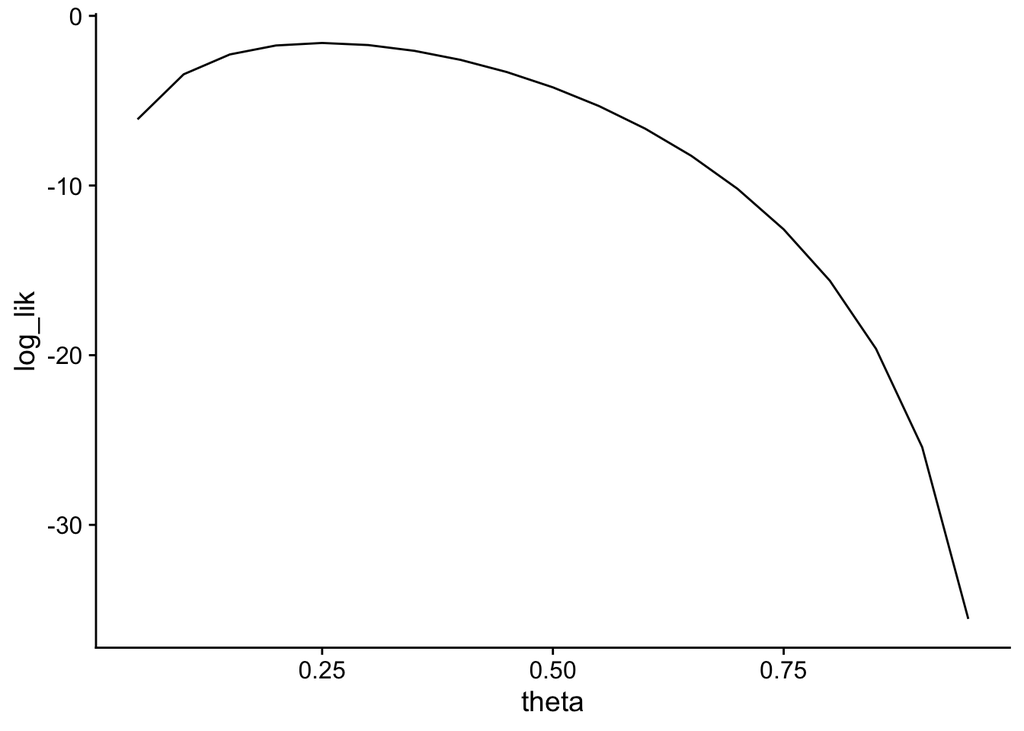

```r
# FIXME
theta <- seq(0.05, 0.95, by  = 0.05)
log_lik <- dbinom(5, 20, prob = theta, log = TRUE)
p <- tibble(theta, log_lik) |>
  ggplot(aes(theta, log_lik)) +
  geom_line()
p # Print the plot.
```

Use `which.max()` to extract the value of $\theta$ that maximizes the log-likelihood. Refer to the lecture slides if you need a reminder.

```r
# FIXME
theta[which.max(log_lik)]
```

```
## [1] 0.25
```

Re-plot the data and add a large, colorful point with `geom_point()` located at the MLE. The full list of colors available in R is at http://www.stat.columbia.edu/~tzheng/files/Rcolor.pdf

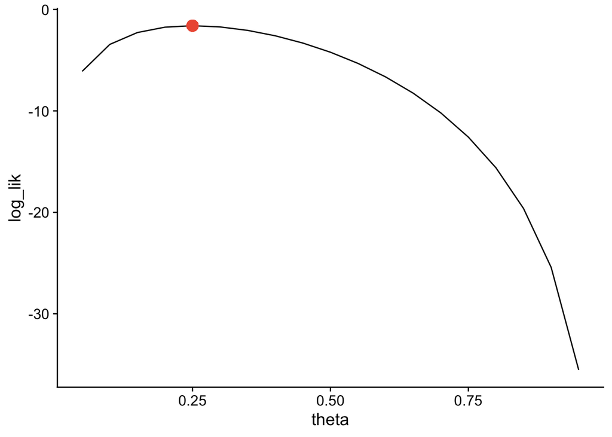

```r
# FIXME
# Notice how we assigned the plot to a variable p above.
# Here we can just add the point.
p +
  geom_point(aes(x = theta[which.max(log_lik)], y = max(log_lik)),
             color = "tomato2", size = 4)
```

Under certain circumstances the ratio of two probabilities (likelihoods) can be interpreted as a test of one model compared to another. In this case we have two models, (1) the maximum likelihood estimate of the probability of heads and (2) the null model that the coin is fair ($Pr[Heads] = 0.5$).

Calculate the probabilities (not on the log-scale) of observing 5 heads given:

1. Your maximum likelihood estimate above.
2. The null probability of 0.5

```r
# FIXME
P0.25 <- dbinom(5, 20, 0.25)
P0.50 <- dbinom(5, 20, 0.50)
```

Now calculate the ratio of the first model to the second. This quantity is called a *Bayes Factor*, which can be interpreted as the strength of the evidence of one model compared to another.

```r
# FIXME
P0.25 / P0.50
```

```
## [1] 13.68418
```

Interpretations of Bayes Factors are:[^2]

1. $< 3.2$: Not worth a mention
2. $3.2 - 10$: Substantial
3. $10 - 100$: Strong
4. $> 100$: Decisive

What is you interpretation of the Bayes Factor for the MLE vs. the null probability of 0.5?

> BF = 13.7, so this is strong evidence that the coin is *not* fair.

What is the probability of observing these data or anything more extreme (fewer heads) if the probability of heads is 0.5?

```r
# FIXME
sum(dbinom(0:5, 20, 0.5))
```

```
## [1] 0.02069473
```

You win the next two coin flips and get to choose the restaurant. Update your calculations of the Bayes Factor and probability as above.

```r
# FIXME
dbinom(7, 22, 7/22) / dbinom(7, 22, 0.50)
```

```
## [1] 4.430126
```

```r
sum(dbinom(0:7, 22, 0.5))
```

```
## [1] 0.06690025
```

What do you conclude about the coin now?

> The evidence is not as strong that it is unfair. But this outcome is still pretty unlikely.

## Adaptation to drought stress in Silver Fir

The Silver Fir (*Abies alba*) is a widespread evergreen conifer tree native to the mountainous regions of Europe. Csillery and colleagues carried out a very large (n > 8,000 measurements) greenhouse experiment to study the genetic adaptations to drought tolerance in *Abies*. We are going to work with a part of this dataset to explore the mean and median.

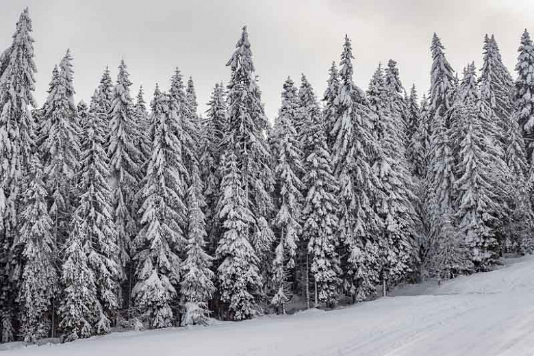

### Activity

Load the data in the file `Silver_fir.xlsx`. Determine how missing data were coded in the file and pass the appropriate argument for NAs. The columns `family` and `block` are numeric, but should be converted to factors. Examine the resulting file with `str()` or `glimpse()`.

```r
# FIXME
M <- read_excel("../data/Silver_fir.xlsx", na = "NA") |>
  mutate(family = factor(family),
         block = factor(block))

glimpse(M)
```

```
## Rows: 8,199
## Columns: 14
## $ id         <chr> "101_1", "101_2", "101_3", "101_4", "101_5", "101_6", "101_…
## $ family     <fct> 801, 801, 801, 801, 801, 801, 801, 801, 801, 801, 801, 801,…
## $ population <chr> "BAY", "BAY", "BAY", "BAY", "BAY", "BAY", "BAY", "BAY", "BA…
## $ block      <fct> 1, 1, 1, 1, 2, 4, 2, 2, 3, 2, 2, 3, 4, 3, 3, 4, 4, 2, 2, 2,…
## $ sw         <dbl> 63.0, 63.0, 63.0, 63.0, 63.0, 63.0, 63.0, 63.0, 63.0, 63.0,…
## $ bb_cum97   <dbl> 8, 6, 7, 8, 7, 6, 6, 9, 4, 4, 6, 7, 8, 6, 9, 6, 6, 6, 9, 9,…
## $ bb_cum98   <dbl> 6, 5, 2, 10, 7, NA, 6, 9, NA, 5, 9, 5, 8, NA, 6, NA, 4, 7, …
## $ bb_cum99   <dbl> NA, NA, NA, NA, NA, 8, NA, NA, 6, NA, NA, 3, 6, 5, 7, 6, 7,…
## $ ht99mm     <dbl> NA, NA, NA, NA, NA, 125, NA, NA, 100, NA, NA, NA, 110, 115,…
## $ ht98mm     <dbl> NA, NA, NA, NA, NA, 120, NA, NA, NA, NA, NA, 170, 90, NA, N…
## $ ht97mm     <dbl> NA, NA, NA, NA, NA, 90, NA, NA, NA, NA, NA, 100, NA, NA, NA…
## $ growth_97  <dbl> 580, 560, 500, 600, 520, 360, 520, 260, 120, 330, 450, 470,…
## $ ws_sum     <dbl> 5, 6, 2, 4, 5, NA, 5, 1, NA, 2, 7, NA, NA, NA, NA, NA, NA, …
## $ ws_wsum    <dbl> 1.0360402, 1.9109857, 0.4618534, 1.2309267, 1.7704614, NA, …
```

These data have several layers of nesting. Each seedling has a unique `id` and comes from one of 16 `population`s. Within each `population`, multiple plants come from each `block` within a `family`.

Group these data by `population`, `family`, and `block`, and then tally the number of observations in each subgroup.

```r
# FIXME
M |>
  count(population, family, block)
```

```
## # A tibble: 1,807 × 4
##    population family block     n
##    <chr>      <fct>  <fct> <int>
##  1 BAY        801    1         4
##  2 BAY        801    2         5
##  3 BAY        801    3         4
##  4 BAY        801    4         4
##  5 BAY        802    1         5
##  6 BAY        802    2         5
##  7 BAY        802    3         5
##  8 BAY        802    4         5
##  9 BAY        803    1         4
## 10 BAY        803    2         4
## # … with 1,797 more rows
```

```r
M |>
  count(population, family, block) |>
  summarize(mean_n = mean(n))
```

```
## # A tibble: 1 × 1
##   mean_n
##    <dbl>
## 1   4.54
```

About how many seedlings are at the smallest replicate `block` level of the data?

> 4 or 5 it seems. 4.54 to be exact

We want to look at the distributions of maximum heights (the `ht` columns). Height was measured in three different years: `ht97mm`, `ht98mm`, `ht99mm`. However not all seedlings have measurements for all years. We want to figure out how to only take the maximum value across the three columns for each seedling (`id`).

Start by selecting `population`, `id`, and the three columns that start with `ht`. For the last you can use the `starts_with()` function. You should have just 5 columns in the resulting tibble.

```r
# FIXME
M_sub <- M |>
  select(population, id, starts_with("ht"))
M_sub |> slice(1:20)
```

```
## # A tibble: 20 × 5
##    population id     ht99mm ht98mm ht97mm
##    <chr>      <chr>   <dbl>  <dbl>  <dbl>
##  1 BAY        101_1      NA     NA     NA
##  2 BAY        101_2      NA     NA     NA
##  3 BAY        101_3      NA     NA     NA
##  4 BAY        101_4      NA     NA     NA
##  5 BAY        101_5      NA     NA     NA
##  6 BAY        101_6     125    120     90
##  7 BAY        101_7      NA     NA     NA
##  8 BAY        101_8      NA     NA     NA
##  9 BAY        101_9     100     NA     NA
## 10 BAY        101_10     NA     NA     NA
## 11 BAY        101_11     NA     NA     NA
## 12 BAY        101_12     NA    170    100
## 13 BAY        101_13    110     90     NA
## 14 BAY        101_14    115     NA     NA
## 15 BAY        101_15    140     NA     NA
## 16 BAY        101_16    225    135     NA
## 17 BAY        101_17    130    110     NA
## 18 BAY        101_18     NA     NA     NA
## 19 BAY        101_19     NA     NA     NA
## 20 BAY        102_1      NA     NA     NA
```

If you print out the first ~20 rows, you can see that there are a lot of NAs. Some seedlings have 3 measurements, some 2, some 1, and some none.

Next pivot the data to long format on the three height columns (you can use `starts_with()` as above). You should then drop rows with NAs in the resulting value column.

```r
# FIXME
M_long <- M_sub |>
  pivot_longer(cols = starts_with("ht")) |>
  drop_na(value)

M_long
```

```
## # A tibble: 6,286 × 4
##    population id     name   value
##    <chr>      <chr>  <chr>  <dbl>
##  1 BAY        101_6  ht99mm   125
##  2 BAY        101_6  ht98mm   120
##  3 BAY        101_6  ht97mm    90
##  4 BAY        101_9  ht99mm   100
##  5 BAY        101_12 ht98mm   170
##  6 BAY        101_12 ht97mm   100
##  7 BAY        101_13 ht99mm   110
##  8 BAY        101_13 ht98mm    90
##  9 BAY        101_14 ht99mm   115
## 10 BAY        101_15 ht99mm   140
## # … with 6,276 more rows
```

6,286 rows should remain. If you print the new tibble you will see that the first seedling (“101_6”) has three measurements: 90, 120, and 125. We can group this new tibble on `population` and `id` and then summarize on the maximum (`max()`) of value to only get the largest value of height for each seedling. Do this below and then check that `id` “101_6” has a value of 125. This will confirm that your summarizing worked correctly.

```r
# FIXME
M_agr <- M_long |>
  group_by(population, id) |>
  summarize(max_height = max(value),
            .groups = "drop")

M_agr |> filter(id == "101_6")
```

```
## # A tibble: 1 × 3
##   population id    max_height
##   <chr>      <chr>      <dbl>
## 1 BAY        101_6        125
```

3,798 rows should remain now. Plot the density of the distribution of maximum height and color by population. Use `facet_wrap()` to plot each population in a separate panel. If the x axis labs collide with each other add `theme(axis.text.x = element_text(angle = 90))` to rotate the axis labels by 90 degrees.

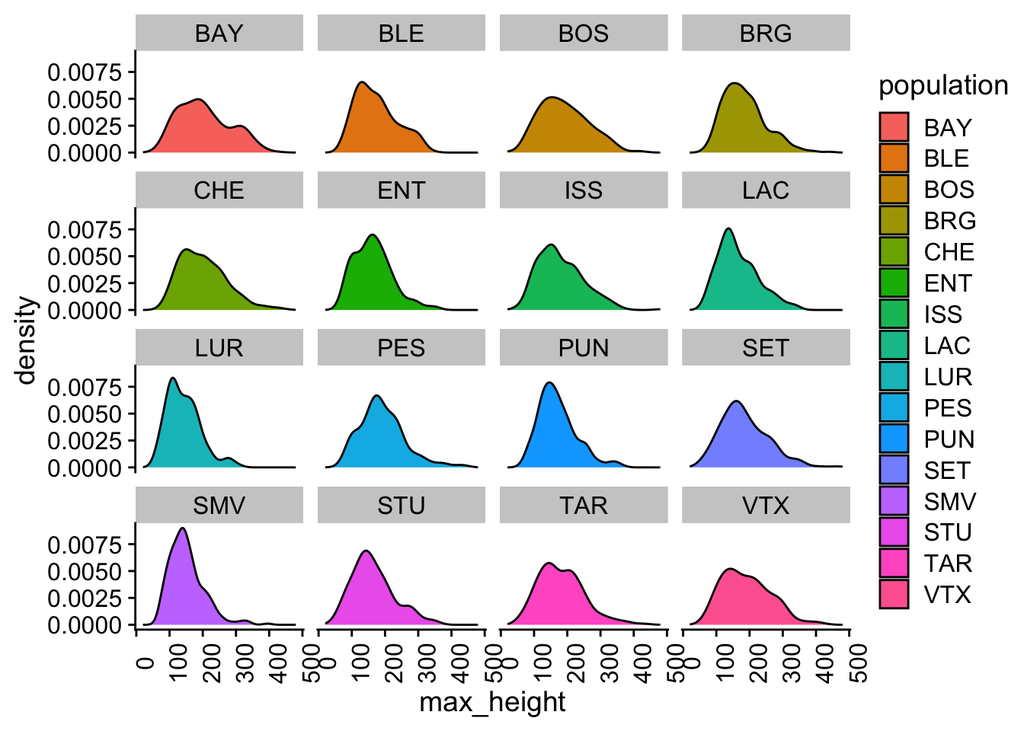

```r
# FIXME
ggplot(M_agr, aes(max_height, fill = population)) +
  geom_density() +
  facet_wrap("population") +
  theme(axis.text.x = element_text(angle = 90))
```

Now summarize the maximum length by population by calculating the mean and the median. Put these values into a tibble and use `knitr::kable()` to print out the table.

```r
# FIXME
M_agr_summary <- M_agr |>
  group_by(population) |>
  summarize(mean_max_height = mean(max_height),
            median_max_height = median(max_height),
            .groups = "drop")
knitr::kable(M_agr_summary)
```

| population | mean_max_height | median_max_height |
| --- | --- | --- |
| BAY | 204.5344 | 195.0 |
| BLE | 174.5854 | 165.0 |
| BOS | 190.6107 | 182.5 |
| BRG | 184.5181 | 175.0 |
| CHE | 201.0195 | 195.0 |
| ENT | 164.2554 | 160.0 |
| ISS | 180.3268 | 170.0 |
| LAC | 165.9770 | 150.0 |
| LUR | 142.3860 | 140.0 |
| PES | 191.8235 | 180.0 |
| PUN | 170.7989 | 160.0 |
| SET | 185.5750 | 170.0 |
| SMV | 151.2807 | 145.0 |
| STU | 164.5000 | 155.0 |
| TAR | 181.9756 | 175.0 |
| VTX | 190.6701 | 180.0 |

Compare the mean and the median across the populations. In this sample is the mean a good estimate of the central tendency?

Finally, let’s add vertical lines to the density plot from above. To do this, we need to be able to plot data from two different tibbles into the same plot. So far, we have been using the general construction: `ggplot(D, aes(y)) + geom_density()`. You can also write this as `ggplot() + geom_density(data = D, aes(y))`. Essentially, you put the data and aesthetic into the geom. This is how you can plot data from multiple different tibbles into the same plot.

- Start by copying the code above into the chunk below.
- Modify the code to match the `ggplot() + geom_density(data = D, aes(y))` format.
- Verify that your plot still looks correct.
- Add two calls to `geom_vline(data = ..., aes(xintercept = ...)` to add the mean and median. Make the two vertical lines different colors.

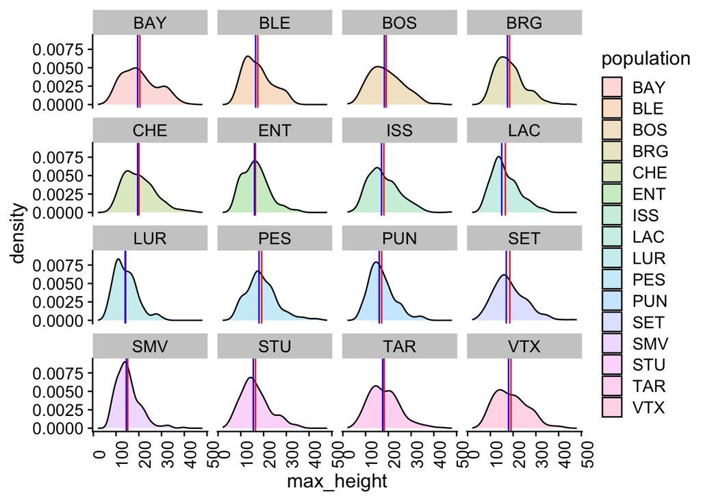

```r
# FIXME
ggplot() +
  geom_density(data = M_agr, aes(max_height, fill = population),
               alpha = 0.25) +
  geom_vline(data = M_agr_summary, aes(xintercept = mean_max_height),
             color = "red") +
  geom_vline(data = M_agr_summary, aes(xintercept = median_max_height),
             color = "blue") +
  facet_wrap("population") +
  theme(axis.text.x = element_text(angle = 90))
```

[^1]: `do ... while` constructions are much less common. In the long run, it’s worth learning the `map_` family functions from tidyverse, because they allow you to efficiently do many of the same things, but their use is not at all straightforward until you have a good handle on writing your own functions.
[^2]: Kass R, Raftery AE. 1995. Bayes factors. *J Am Stat Assoc* 90:773-795.